# Risk Factor Analysis

## Outcome Variable

**Outcome Variable:** ever_stunted

## Predictor Variables

**Intervention Variable:** meducyrs

**Adjustment Set:**

unadjusted

## Stratifying Variables

The analysis was stratified on these variable(s):

- agecat
- studyid

The following strata were considered:

- agecat: 12 months, studyid: ki0047075b-MAL-ED
- agecat: 12 months, studyid: ki1000108-CMC-V-BCS-2002
- agecat: 12 months, studyid: ki1000108-IRC
- agecat: 12 months, studyid: ki1000109-EE
- agecat: 12 months, studyid: ki1000304b-SAS-FoodSuppl
- agecat: 12 months, studyid: ki1017093-NIH-Birth
- agecat: 12 months, studyid: ki1017093b-PROVIDE
- agecat: 12 months, studyid: ki1017093c-NIH-Crypto
- agecat: 12 months, studyid: ki1066203-TanzaniaChild2
- agecat: 12 months, studyid: ki1112895-Guatemala BSC
- agecat: 12 months, studyid: ki1113344-GMS-Nepal
- agecat: 12 months, studyid: ki1126311-ZVITAMBO
- agecat: 12 months, studyid: ki1135781-COHORTS
- agecat: 12 months, studyid: ki1148112-LCNI-5
- agecat: 18 months, studyid: ki0047075b-MAL-ED
- agecat: 18 months, studyid: ki1000108-CMC-V-BCS-2002
- agecat: 18 months, studyid: ki1000108-IRC
- agecat: 18 months, studyid: ki1000109-EE
- agecat: 18 months, studyid: ki1000304b-SAS-FoodSuppl
- agecat: 18 months, studyid: ki1017093-NIH-Birth
- agecat: 18 months, studyid: ki1017093b-PROVIDE
- agecat: 18 months, studyid: ki1017093c-NIH-Crypto
- agecat: 18 months, studyid: ki1066203-TanzaniaChild2
- agecat: 18 months, studyid: ki1112895-Guatemala BSC
- agecat: 18 months, studyid: ki1113344-GMS-Nepal
- agecat: 18 months, studyid: ki1126311-ZVITAMBO
- agecat: 18 months, studyid: ki1135781-COHORTS
- agecat: 18 months, studyid: ki1148112-LCNI-5
- agecat: 24 months, studyid: ki0047075b-MAL-ED
- agecat: 24 months, studyid: ki1000108-CMC-V-BCS-2002
- agecat: 24 months, studyid: ki1000108-IRC
- agecat: 24 months, studyid: ki1000109-EE
- agecat: 24 months, studyid: ki1000304b-SAS-FoodSuppl
- agecat: 24 months, studyid: ki1017093-NIH-Birth
- agecat: 24 months, studyid: ki1017093b-PROVIDE
- agecat: 24 months, studyid: ki1017093c-NIH-Crypto
- agecat: 24 months, studyid: ki1066203-TanzaniaChild2
- agecat: 24 months, studyid: ki1113344-GMS-Nepal
- agecat: 24 months, studyid: ki1126311-ZVITAMBO
- agecat: 24 months, studyid: ki1135781-COHORTS
- agecat: 24 months, studyid: ki1148112-LCNI-5
- agecat: 3 months, studyid: ki0047075b-MAL-ED
- agecat: 3 months, studyid: ki1000108-CMC-V-BCS-2002
- agecat: 3 months, studyid: ki1000108-IRC
- agecat: 3 months, studyid: ki1000109-EE
- agecat: 3 months, studyid: ki1017093-NIH-Birth
- agecat: 3 months, studyid: ki1017093b-PROVIDE
- agecat: 3 months, studyid: ki1017093c-NIH-Crypto
- agecat: 3 months, studyid: ki1066203-TanzaniaChild2
- agecat: 3 months, studyid: ki1113344-GMS-Nepal
- agecat: 3 months, studyid: ki1126311-ZVITAMBO
- agecat: 3 months, studyid: ki1135781-COHORTS
- agecat: 6 months, studyid: ki0047075b-MAL-ED
- agecat: 6 months, studyid: ki1000108-CMC-V-BCS-2002
- agecat: 6 months, studyid: ki1000108-IRC
- agecat: 6 months, studyid: ki1000109-EE
- agecat: 6 months, studyid: ki1000304b-SAS-FoodSuppl
- agecat: 6 months, studyid: ki1017093-NIH-Birth
- agecat: 6 months, studyid: ki1017093b-PROVIDE
- agecat: 6 months, studyid: ki1017093c-NIH-Crypto
- agecat: 6 months, studyid: ki1066203-TanzaniaChild2
- agecat: 6 months, studyid: ki1112895-Guatemala BSC
- agecat: 6 months, studyid: ki1113344-GMS-Nepal
- agecat: 6 months, studyid: ki1126311-ZVITAMBO
- agecat: 6 months, studyid: ki1135781-COHORTS
- agecat: 6 months, studyid: ki1148112-LCNI-5

### Dropped Strata

Some strata were dropped due to rare outcomes:

- agecat: 3 months, studyid: ki1000108-CMC-V-BCS-2002
- agecat: 3 months, studyid: ki1000108-IRC
- agecat: 3 months, studyid: ki1000109-EE
- agecat: 3 months, studyid: ki1017093b-PROVIDE
- agecat: 3 months, studyid: ki1066203-TanzaniaChild2
- agecat: 3 months, studyid: ki1113344-GMS-Nepal
- agecat: 6 months, studyid: ki1000108-CMC-V-BCS-2002
- agecat: 6 months, studyid: ki1000109-EE
- agecat: 6 months, studyid: ki1000304b-SAS-FoodSuppl
- agecat: 6 months, studyid: ki1017093b-PROVIDE
- agecat: 6 months, studyid: ki1066203-TanzaniaChild2
- agecat: 6 months, studyid: ki1112895-Guatemala BSC
- agecat: 6 months, studyid: ki1148112-LCNI-5
- agecat: 12 months, studyid: ki1000108-CMC-V-BCS-2002
- agecat: 12 months, studyid: ki1000109-EE
- agecat: 12 months, studyid: ki1000304b-SAS-FoodSuppl
- agecat: 12 months, studyid: ki1017093b-PROVIDE
- agecat: 12 months, studyid: ki1066203-TanzaniaChild2
- agecat: 12 months, studyid: ki1112895-Guatemala BSC
- agecat: 18 months, studyid: ki1000108-CMC-V-BCS-2002
- agecat: 18 months, studyid: ki1000109-EE
- agecat: 18 months, studyid: ki1000304b-SAS-FoodSuppl
- agecat: 18 months, studyid: ki1017093b-PROVIDE
- agecat: 18 months, studyid: ki1066203-TanzaniaChild2
- agecat: 18 months, studyid: ki1112895-Guatemala BSC
- agecat: 24 months, studyid: ki1000108-CMC-V-BCS-2002
- agecat: 24 months, studyid: ki1000109-EE
- agecat: 24 months, studyid: ki1000304b-SAS-FoodSuppl
- agecat: 24 months, studyid: ki1017093b-PROVIDE
- agecat: 24 months, studyid: ki1066203-TanzaniaChild2
- agecat: 24 months, studyid: ki1126311-ZVITAMBO

## Methods Detail

We’re interested in the causal parameters $E[Y_a]$ for all values of $a \in \mathcal{A}$. These parameters represent the mean outcome if, possibly contrary to fact, we intervened to set all units to have $A=a$. Under the randomization and positivity assumptions, these are identified by the statistical parameters $\psi_a=E_W[E_{Y|A,W}(Y|A=a,W)]$. In addition, we’re interested in the mean of $Y$, $E[Y]$ under no intervention (the observed mean). We will estimate these parameters by using SuperLearner to fit the relevant likelihood factors – $E_{Y|A,W}(Y|A=a,W)$ and $p(A=a|W)$, and then updating our likelihood fit using a joint TMLE.

For unadjusted analyses ($W=\{\}$), initial likelihoods were estimated using Lrnr_glm to estimate the simple $E(Y|A)$ and Lrnr_mean to estimate $p(A)$. For adjusted analyses, a small library containing Lrnr_glmnet, Lrnr_xgboost, and Lrnr_mean was used.

Having estimated these parameters, we will then use the delta method to estimate relative risks and attributable risks relative to a prespecified baseline level of $A$.

# Results Detail

## Results Plots

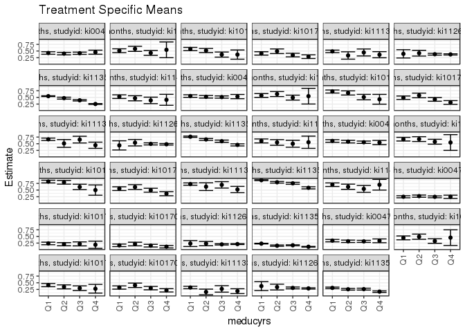

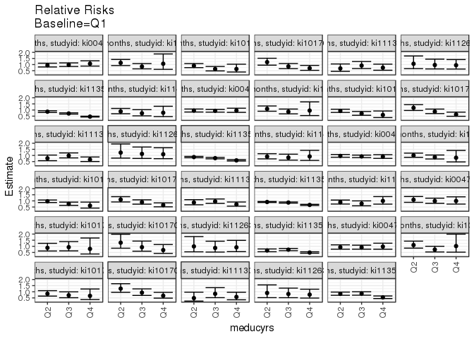

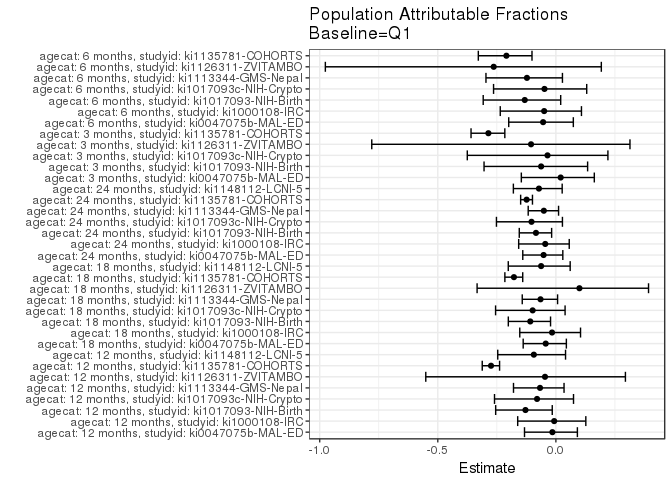

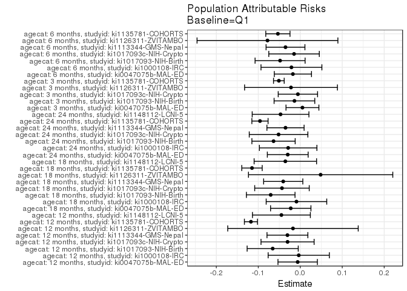

## Data Summary

| agecat | studyid | A | n | nA | nAY0 | nAY1 |
| --- | --- | --- | --- | --- | --- | --- |
| 3 months | ki0047075b-MAL-ED | Q1 | 1724 | 469 | 352 | 117 |
| 3 months | ki0047075b-MAL-ED | Q2 | 1724 | 466 | 339 | 127 |
| 3 months | ki0047075b-MAL-ED | Q3 | 1724 | 599 | 451 | 148 |
| 3 months | ki0047075b-MAL-ED | Q4 | 1724 | 190 | 143 | 47 |
| 3 months | ki1000108-CMC-V-BCS-2002 | Q1 | 362 | 100 | 69 | 31 |
| 3 months | ki1000108-CMC-V-BCS-2002 | Q2 | 362 | 195 | 117 | 78 |
| 3 months | ki1000108-CMC-V-BCS-2002 | Q3 | 362 | 58 | 45 | 13 |
| 3 months | ki1000108-CMC-V-BCS-2002 | Q4 | 362 | 9 | 6 | 3 |
| 3 months | ki1000108-IRC | Q1 | 410 | 182 | 124 | 58 |
| 3 months | ki1000108-IRC | Q2 | 410 | 104 | 64 | 40 |
| 3 months | ki1000108-IRC | Q3 | 410 | 113 | 83 | 30 |
| 3 months | ki1000108-IRC | Q4 | 410 | 11 | 9 | 2 |
| 3 months | ki1000109-EE | Q1 | 376 | 328 | 118 | 210 |
| 3 months | ki1000109-EE | Q2 | 376 | 33 | 13 | 20 |
| 3 months | ki1000109-EE | Q3 | 376 | 11 | 4 | 7 |
| 3 months | ki1000109-EE | Q4 | 376 | 4 | 2 | 2 |
| 3 months | ki1000304b-SAS-FoodSuppl | Q1 | 0 | 0 | 0 | 0 |
| 3 months | ki1000304b-SAS-FoodSuppl | Q2 | 0 | 0 | 0 | 0 |
| 3 months | ki1000304b-SAS-FoodSuppl | Q3 | 0 | 0 | 0 | 0 |
| 3 months | ki1000304b-SAS-FoodSuppl | Q4 | 0 | 0 | 0 | 0 |
| 3 months | ki1017093-NIH-Birth | Q1 | 629 | 296 | 226 | 70 |
| 3 months | ki1017093-NIH-Birth | Q2 | 629 | 183 | 145 | 38 |
| 3 months | ki1017093-NIH-Birth | Q3 | 629 | 118 | 92 | 26 |
| 3 months | ki1017093-NIH-Birth | Q4 | 629 | 32 | 26 | 6 |
| 3 months | ki1017093b-PROVIDE | Q1 | 175 | 85 | 61 | 24 |
| 3 months | ki1017093b-PROVIDE | Q2 | 175 | 63 | 48 | 15 |
| 3 months | ki1017093b-PROVIDE | Q3 | 175 | 24 | 20 | 4 |
| 3 months | ki1017093b-PROVIDE | Q4 | 175 | 3 | 2 | 1 |
| 3 months | ki1017093c-NIH-Crypto | Q1 | 758 | 242 | 202 | 40 |
| 3 months | ki1017093c-NIH-Crypto | Q2 | 758 | 140 | 110 | 30 |

[output cut: 250 more lines]

## Results Table

### Parameter: TSM

| agecat | studyid | intervention_level | baseline_level | estimate | ci_lower | ci_upper |
| --- | --- | --- | --- | --- | --- | --- |
| 3 months | ki0047075b-MAL-ED | Q1 | NA | 0.2494670 | 0.2102947 | 0.2886393 |
| 3 months | ki0047075b-MAL-ED | Q2 | NA | 0.2725322 | 0.2320935 | 0.3129709 |
| 3 months | ki0047075b-MAL-ED | Q3 | NA | 0.2470785 | 0.2125281 | 0.2816289 |
| 3 months | ki0047075b-MAL-ED | Q4 | NA | 0.2473684 | 0.1859978 | 0.3087391 |
| 3 months | ki1017093-NIH-Birth | Q1 | NA | 0.2364865 | 0.1880403 | 0.2849326 |
| 3 months | ki1017093-NIH-Birth | Q2 | NA | 0.2076503 | 0.1488346 | 0.2664659 |
| 3 months | ki1017093-NIH-Birth | Q3 | NA | 0.2203390 | 0.1454960 | 0.2951820 |
| 3 months | ki1017093-NIH-Birth | Q4 | NA | 0.1875000 | 0.0521585 | 0.3228415 |
| 3 months | ki1017093c-NIH-Crypto | Q1 | NA | 0.1652893 | 0.1184600 | 0.2121185 |
| 3 months | ki1017093c-NIH-Crypto | Q2 | NA | 0.2142857 | 0.1462715 | 0.2822999 |
| 3 months | ki1017093c-NIH-Crypto | Q3 | NA | 0.1534653 | 0.1037275 | 0.2032032 |
| 3 months | ki1017093c-NIH-Crypto | Q4 | NA | 0.1149425 | 0.0675198 | 0.1623652 |
| 3 months | ki1126311-ZVITAMBO | Q1 | NA | 0.2321429 | 0.1215482 | 0.3427375 |
| 3 months | ki1126311-ZVITAMBO | Q2 | NA | 0.2307692 | 0.1497831 | 0.3117554 |
| 3 months | ki1126311-ZVITAMBO | Q3 | NA | 0.2015845 | 0.1782519 | 0.2249172 |
| 3 months | ki1126311-ZVITAMBO | Q4 | NA | 0.2128915 | 0.1957953 | 0.2299877 |
| 3 months | ki1135781-COHORTS | Q1 | NA | 0.2295471 | 0.2168536 | 0.2422405 |
| 3 months | ki1135781-COHORTS | Q2 | NA | 0.1519608 | 0.1273287 | 0.1765928 |
| 3 months | ki1135781-COHORTS | Q3 | NA | 0.1672153 | 0.1484482 | 0.1859824 |
| 3 months | ki1135781-COHORTS | Q4 | NA | 0.1126076 | 0.1006232 | 0.1245919 |
| 6 months | ki0047075b-MAL-ED | Q1 | NA | 0.3424036 | 0.2981027 | 0.3867045 |
| 6 months | ki0047075b-MAL-ED | Q2 | NA | 0.3170163 | 0.2729709 | 0.3610617 |
| 6 months | ki0047075b-MAL-ED | Q3 | NA | 0.3140351 | 0.2759210 | 0.3521492 |
| 6 months | ki0047075b-MAL-ED | Q4 | NA | 0.3352941 | 0.2643059 | 0.4062823 |
| 6 months | ki1000108-IRC | Q1 | NA | 0.4450549 | 0.3727651 | 0.5173448 |
| 6 months | ki1000108-IRC | Q2 | NA | 0.4901961 | 0.3930629 | 0.5873292 |
| 6 months | ki1000108-IRC | Q3 | NA | 0.3274336 | 0.2408031 | 0.4140642 |
| 6 months | ki1000108-IRC | Q4 | NA | 0.4545455 | 0.1599320 | 0.7491589 |
| 6 months | ki1017093-NIH-Birth | Q1 | NA | 0.4128788 | 0.3534337 | 0.4723238 |
| 6 months | ki1017093-NIH-Birth | Q2 | NA | 0.3464052 | 0.2709406 | 0.4218698 |

[output cut: 110 more lines]

### Parameter: E(Y)

| agecat | studyid | intervention_level | baseline_level | estimate | ci_lower | ci_upper |
| --- | --- | --- | --- | --- | --- | --- |
| 3 months | ki0047075b-MAL-ED | NA | NA | 0.2546404 | 0.2541242 | 0.2551565 |
| 3 months | ki1017093-NIH-Birth | NA | NA | 0.2225755 | 0.2214170 | 0.2237340 |
| 3 months | ki1017093c-NIH-Crypto | NA | NA | 0.1596306 | 0.1573438 | 0.1619174 |
| 3 months | ki1126311-ZVITAMBO | NA | NA | 0.2100600 | 0.2098282 | 0.2102918 |
| 3 months | ki1135781-COHORTS | NA | NA | 0.1785366 | 0.1775096 | 0.1795636 |
| 6 months | ki0047075b-MAL-ED | NA | NA | 0.3248447 | 0.3242390 | 0.3254504 |
| 6 months | ki1000108-IRC | NA | NA | 0.4240196 | 0.4179517 | 0.4300876 |
| 6 months | ki1017093-NIH-Birth | NA | NA | 0.3647913 | 0.3605794 | 0.3690032 |
| 6 months | ki1017093c-NIH-Crypto | NA | NA | 0.3070652 | 0.3026780 | 0.3114525 |
| 6 months | ki1113344-GMS-Nepal | NA | NA | 0.2872340 | 0.2823028 | 0.2921653 |
| 6 months | ki1126311-ZVITAMBO | NA | NA | 0.2968476 | 0.2962318 | 0.2974635 |
| 6 months | ki1135781-COHORTS | NA | NA | 0.2546689 | 0.2527922 | 0.2565457 |
| 12 months | ki0047075b-MAL-ED | NA | NA | 0.4200385 | 0.4192812 | 0.4207959 |
| 12 months | ki1000108-IRC | NA | NA | 0.5073529 | 0.5018784 | 0.5128274 |
| 12 months | ki1017093-NIH-Birth | NA | NA | 0.5101664 | 0.5031544 | 0.5171783 |
| 12 months | ki1017093c-NIH-Crypto | NA | NA | 0.3799726 | 0.3749564 | 0.3849888 |
| 12 months | ki1113344-GMS-Nepal | NA | NA | 0.4559585 | 0.4515808 | 0.4603363 |
| 12 months | ki1126311-ZVITAMBO | NA | NA | 0.3773585 | 0.3770215 | 0.3776955 |
| 12 months | ki1135781-COHORTS | NA | NA | 0.4281168 | 0.4254875 | 0.4307462 |
| 12 months | ki1148112-LCNI-5 | NA | NA | 0.4821429 | 0.4768617 | 0.4874240 |
| 18 months | ki0047075b-MAL-ED | NA | NA | 0.5271995 | 0.5264343 | 0.5279646 |
| 18 months | ki1000108-IRC | NA | NA | 0.5623472 | 0.5575603 | 0.5671340 |
| 18 months | ki1017093-NIH-Birth | NA | NA | 0.6498994 | 0.6416562 | 0.6581426 |
| 18 months | ki1017093c-NIH-Crypto | NA | NA | 0.4433566 | 0.4368751 | 0.4498382 |
| 18 months | ki1113344-GMS-Nepal | NA | NA | 0.6252189 | 0.6186800 | 0.6317578 |
| 18 months | ki1126311-ZVITAMBO | NA | NA | 0.4859914 | 0.4853795 | 0.4866033 |
| 18 months | ki1135781-COHORTS | NA | NA | 0.6478233 | 0.6437767 | 0.6518698 |
| 18 months | ki1148112-LCNI-5 | NA | NA | 0.5692308 | 0.5648662 | 0.5735953 |
| 24 months | ki0047075b-MAL-ED | NA | NA | 0.5742574 | 0.5731290 | 0.5753859 |
| 24 months | ki1000108-IRC | NA | NA | 0.6414634 | 0.6370434 | 0.6458835 |
| 24 months | ki1017093-NIH-Birth | NA | NA | 0.7553191 | 0.7465217 | 0.7641166 |
| 24 months | ki1017093c-NIH-Crypto | NA | NA | 0.5015773 | 0.4947742 | 0.5083804 |
| 24 months | ki1113344-GMS-Nepal | NA | NA | 0.6902655 | 0.6846453 | 0.6958857 |
| 24 months | ki1135781-COHORTS | NA | NA | 0.7751401 | 0.7713825 | 0.7788977 |
| 24 months | ki1148112-LCNI-5 | NA | NA | 0.6552707 | 0.6490732 | 0.6614681 |

### Parameter: RR

| agecat | studyid | intervention_level | baseline_level | estimate | ci_lower | ci_upper |
| --- | --- | --- | --- | --- | --- | --- |
| 3 months | ki0047075b-MAL-ED | Q2 | Q1 | 1.0924581 | 0.8801963 | 1.3559074 |
| 3 months | ki0047075b-MAL-ED | Q3 | Q1 | 0.9904256 | 0.8026122 | 1.2221879 |
| 3 months | ki0047075b-MAL-ED | Q4 | Q1 | 0.9915879 | 0.7392950 | 1.3299788 |
| 3 months | ki1017093-NIH-Birth | Q2 | Q1 | 0.8780640 | 0.6190322 | 1.2454869 |
| 3 months | ki1017093-NIH-Birth | Q3 | Q1 | 0.9317191 | 0.6266357 | 1.3853352 |
| 3 months | ki1017093-NIH-Birth | Q4 | Q1 | 0.7928571 | 0.3743962 | 1.6790299 |
| 3 months | ki1017093c-NIH-Crypto | Q2 | Q1 | 1.2964286 | 0.8471811 | 1.9839052 |
| 3 months | ki1017093c-NIH-Crypto | Q3 | Q1 | 0.9284653 | 0.6036888 | 1.4279673 |
| 3 months | ki1017093c-NIH-Crypto | Q4 | Q1 | 0.6954023 | 0.4215768 | 1.1470848 |
| 3 months | ki1126311-ZVITAMBO | Q2 | Q1 | 0.9940828 | 0.5501047 | 1.7963867 |
| 3 months | ki1126311-ZVITAMBO | Q3 | Q1 | 0.8683640 | 0.5318409 | 1.4178227 |
| 3 months | ki1126311-ZVITAMBO | Q4 | Q1 | 0.9170711 | 0.5656959 | 1.4866989 |
| 3 months | ki1135781-COHORTS | Q2 | Q1 | 0.6620027 | 0.5578010 | 0.7856701 |
| 3 months | ki1135781-COHORTS | Q3 | Q1 | 0.7284574 | 0.6427866 | 0.8255465 |
| 3 months | ki1135781-COHORTS | Q4 | Q1 | 0.4905641 | 0.4351199 | 0.5530732 |
| 6 months | ki0047075b-MAL-ED | Q2 | Q1 | 0.9258556 | 0.7657591 | 1.1194234 |
| 6 months | ki0047075b-MAL-ED | Q3 | Q1 | 0.9171488 | 0.7680628 | 1.0951734 |
| 6 months | ki0047075b-MAL-ED | Q4 | Q1 | 0.9792365 | 0.7640633 | 1.2550060 |
| 6 months | ki1000108-IRC | Q2 | Q1 | 1.1014282 | 0.8524767 | 1.4230819 |
| 6 months | ki1000108-IRC | Q3 | Q1 | 0.7357151 | 0.5393621 | 1.0035496 |
| 6 months | ki1000108-IRC | Q4 | Q1 | 1.0213244 | 0.5235660 | 1.9923056 |
| 6 months | ki1017093-NIH-Birth | Q2 | Q1 | 0.8389998 | 0.6461823 | 1.0893532 |
| 6 months | ki1017093-NIH-Birth | Q3 | Q1 | 0.7150721 | 0.5146124 | 0.9936179 |
| 6 months | ki1017093-NIH-Birth | Q4 | Q1 | 0.6681430 | 0.3639377 | 1.2266248 |
| 6 months | ki1017093c-NIH-Crypto | Q2 | Q1 | 1.2563725 | 0.9529048 | 1.6564844 |
| 6 months | ki1017093c-NIH-Crypto | Q3 | Q1 | 0.9304230 | 0.7006438 | 1.2355593 |
| 6 months | ki1017093c-NIH-Crypto | Q4 | Q1 | 0.6761569 | 0.4809033 | 0.9506862 |
| 6 months | ki1113344-GMS-Nepal | Q2 | Q1 | 0.4824653 | 0.2405122 | 0.9678211 |
| 6 months | ki1113344-GMS-Nepal | Q3 | Q1 | 0.8350361 | 0.5217090 | 1.3365405 |
| 6 months | ki1113344-GMS-Nepal | Q4 | Q1 | 0.5760045 | 0.3454422 | 0.9604534 |

[output cut: 75 more lines]

### Parameter: PAR

| agecat | studyid | intervention_level | baseline_level | estimate | ci_lower | ci_upper |
| --- | --- | --- | --- | --- | --- | --- |
| 3 months | ki0047075b-MAL-ED | Q1 | NA | 0.0051734 | -0.0340023 | 0.0443491 |
| 3 months | ki1017093-NIH-Birth | Q1 | NA | -0.0139110 | -0.0623710 | 0.0345490 |
| 3 months | ki1017093c-NIH-Crypto | Q1 | NA | -0.0056586 | -0.0525437 | 0.0412264 |
| 3 months | ki1126311-ZVITAMBO | Q1 | NA | -0.0220828 | -0.1326777 | 0.0885120 |
| 3 months | ki1135781-COHORTS | Q1 | NA | -0.0510105 | -0.0637454 | -0.0382756 |
| 6 months | ki0047075b-MAL-ED | Q1 | NA | -0.0175589 | -0.0618640 | 0.0267461 |
| 6 months | ki1000108-IRC | Q1 | NA | -0.0210353 | -0.0935794 | 0.0515087 |
| 6 months | ki1017093-NIH-Birth | Q1 | NA | -0.0480875 | -0.1076816 | 0.0115066 |
| 6 months | ki1017093c-NIH-Crypto | Q1 | NA | -0.0148232 | -0.0750133 | 0.0453670 |
| 6 months | ki1113344-GMS-Nepal | Q1 | NA | -0.0351841 | -0.0814657 | 0.0110975 |
| 6 months | ki1126311-ZVITAMBO | Q1 | NA | -0.0781524 | -0.2459272 | 0.0896224 |
| 6 months | ki1135781-COHORTS | Q1 | NA | -0.0533351 | -0.0822029 | -0.0244674 |
| 12 months | ki0047075b-MAL-ED | Q1 | NA | -0.0061910 | -0.0531178 | 0.0407358 |
| 12 months | ki1000108-IRC | Q1 | NA | -0.0036361 | -0.0765546 | 0.0692824 |
| 12 months | ki1017093-NIH-Birth | Q1 | NA | -0.0657091 | -0.1265918 | -0.0048264 |
| 12 months | ki1017093c-NIH-Crypto | Q1 | NA | -0.0302838 | -0.0935493 | 0.0329817 |
| 12 months | ki1113344-GMS-Nepal | Q1 | NA | -0.0305940 | -0.0792726 | 0.0180846 |
| 12 months | ki1126311-ZVITAMBO | Q1 | NA | -0.0173784 | -0.1728204 | 0.1380637 |
| 12 months | ki1135781-COHORTS | Q1 | NA | -0.1175402 | -0.1331162 | -0.1019641 |
| 12 months | ki1148112-LCNI-5 | Q1 | NA | -0.0449507 | -0.1139212 | 0.0240197 |
| 18 months | ki0047075b-MAL-ED | Q1 | NA | -0.0226789 | -0.0707990 | 0.0254412 |
| 18 months | ki1000108-IRC | Q1 | NA | -0.0090814 | -0.0812245 | 0.0630617 |
| 18 months | ki1017093-NIH-Birth | Q1 | NA | -0.0704396 | -0.1283503 | -0.0125289 |
| 18 months | ki1017093c-NIH-Crypto | Q1 | NA | -0.0435999 | -0.1085653 | 0.0213656 |
| 18 months | ki1113344-GMS-Nepal | Q1 | NA | -0.0406165 | -0.0872852 | 0.0060522 |
| 18 months | ki1126311-ZVITAMBO | Q1 | NA | 0.0484914 | -0.1234353 | 0.2204180 |
| 18 months | ki1135781-COHORTS | Q1 | NA | -0.1150291 | -0.1393768 | -0.0906815 |
| 18 months | ki1148112-LCNI-5 | Q1 | NA | -0.0355596 | -0.1099513 | 0.0388320 |
| 24 months | ki0047075b-MAL-ED | Q1 | NA | -0.0298557 | -0.0784839 | 0.0187726 |
| 24 months | ki1000108-IRC | Q1 | NA | -0.0288663 | -0.0973886 | 0.0396561 |
| 24 months | ki1017093-NIH-Birth | Q1 | NA | -0.0636854 | -0.1152562 | -0.0121145 |
| 24 months | ki1017093c-NIH-Crypto | Q1 | NA | -0.0517222 | -0.1215323 | 0.0180879 |
| 24 months | ki1113344-GMS-Nepal | Q1 | NA | -0.0351753 | -0.0794729 | 0.0091223 |
| 24 months | ki1135781-COHORTS | Q1 | NA | -0.0960153 | -0.1153197 | -0.0767110 |
| 24 months | ki1148112-LCNI-5 | Q1 | NA | -0.0469765 | -0.1145328 | 0.0205797 |

### Parameter: PAF

| agecat | studyid | intervention_level | baseline_level | estimate | ci_lower | ci_upper |
| --- | --- | --- | --- | --- | --- | --- |
| 3 months | ki0047075b-MAL-ED | Q1 | NA | 0.0203166 | -0.1462678 | 0.1626917 |
| 3 months | ki1017093-NIH-Birth | Q1 | NA | -0.0625000 | -0.3041464 | 0.1343715 |
| 3 months | ki1017093c-NIH-Crypto | Q1 | NA | -0.0354484 | -0.3750823 | 0.2202988 |
| 3 months | ki1126311-ZVITAMBO | Q1 | NA | -0.1051263 | -0.7795643 | 0.3137060 |
| 3 months | ki1135781-COHORTS | Q1 | NA | -0.2857145 | -0.3592195 | -0.2161845 |
| 6 months | ki0047075b-MAL-ED | Q1 | NA | -0.0540532 | -0.1996604 | 0.0738810 |
| 6 months | ki1000108-IRC | Q1 | NA | -0.0496094 | -0.2355005 | 0.1083130 |
| 6 months | ki1017093-NIH-Birth | Q1 | NA | -0.1318220 | -0.3076974 | 0.0203996 |
| 6 months | ki1017093c-NIH-Crypto | Q1 | NA | -0.0482738 | -0.2638778 | 0.1305505 |
| 6 months | ki1113344-GMS-Nepal | Q1 | NA | -0.1224928 | -0.2960339 | 0.0278109 |
| 6 months | ki1126311-ZVITAMBO | Q1 | NA | -0.2632743 | -0.9760666 | 0.1924047 |
| 6 months | ki1135781-COHORTS | Q1 | NA | -0.2094292 | -0.3283870 | -0.1011242 |
| 12 months | ki0047075b-MAL-ED | Q1 | NA | -0.0147391 | -0.1328419 | 0.0910512 |
| 12 months | ki1000108-IRC | Q1 | NA | -0.0071667 | -0.1616573 | 0.1267779 |
| 12 months | ki1017093-NIH-Birth | Q1 | NA | -0.1287994 | -0.2549160 | -0.0153573 |
| 12 months | ki1017093c-NIH-Crypto | Q1 | NA | -0.0797001 | -0.2598256 | 0.0746717 |
| 12 months | ki1113344-GMS-Nepal | Q1 | NA | -0.0670982 | -0.1794487 | 0.0345501 |
| 12 months | ki1126311-ZVITAMBO | Q1 | NA | -0.0460526 | -0.5508612 | 0.2944397 |
| 12 months | ki1135781-COHORTS | Q1 | NA | -0.2745517 | -0.3117903 | -0.2383701 |
| 12 months | ki1148112-LCNI-5 | Q1 | NA | -0.0932312 | -0.2461553 | 0.0409266 |
| 18 months | ki0047075b-MAL-ED | Q1 | NA | -0.0430177 | -0.1384065 | 0.0443784 |
| 18 months | ki1000108-IRC | Q1 | NA | -0.0161491 | -0.1528988 | 0.1043803 |
| 18 months | ki1017093-NIH-Birth | Q1 | NA | -0.1083854 | -0.2013957 | -0.0225758 |
| 18 months | ki1017093c-NIH-Crypto | Q1 | NA | -0.0983404 | -0.2552672 | 0.0389682 |
| 18 months | ki1113344-GMS-Nepal | Q1 | NA | -0.0649636 | -0.1423909 | 0.0072158 |
| 18 months | ki1126311-ZVITAMBO | Q1 | NA | 0.0997783 | -0.3335713 | 0.3923091 |
| 18 months | ki1135781-COHORTS | Q1 | NA | -0.1775625 | -0.2159592 | -0.1403783 |
| 18 months | ki1148112-LCNI-5 | Q1 | NA | -0.0624697 | -0.2015679 | 0.0605260 |
| 24 months | ki0047075b-MAL-ED | Q1 | NA | -0.0519901 | -0.1401744 | 0.0293738 |
| 24 months | ki1000108-IRC | Q1 | NA | -0.0450006 | -0.1574958 | 0.0565614 |
| 24 months | ki1017093-NIH-Birth | Q1 | NA | -0.0843158 | -0.1549739 | -0.0179804 |
| 24 months | ki1017093c-NIH-Crypto | Q1 | NA | -0.1031191 | -0.2516243 | 0.0277659 |
| 24 months | ki1113344-GMS-Nepal | Q1 | NA | -0.0509591 | -0.1171911 | 0.0113463 |
| 24 months | ki1135781-COHORTS | Q1 | NA | -0.1238683 | -0.1491772 | -0.0991168 |
| 24 months | ki1148112-LCNI-5 | Q1 | NA | -0.0716903 | -0.1799798 | 0.0266613 |